# R1 — Calidad y preparación de los datos

ENGIH 2018, República Dominicana | Análisis preliminar de Secciones 2 y 3A

Autor/a

Maicel E. Monzón

Fecha de publicación

12 de septiembre de 2026

> **Cómo leer este documento.** Todas las cifras se calculan al momento de renderizar, directamente desde los archivos del pipeline. No hay ningún número escrito a mano. Si los datos mejoran, este reporte mejora solo.

> Fecha de generación: 12-09-2026.

## 1 Qué responde este reporte

Los Términos de Referencia (numerales 4.1 a 4.3) piden un dictamen sobre si la ENGIH 2018 permite implementar una metodología de estimación de ingesta de micronutrientes: qué variables sirven, cuáles no están disponibles, y qué adaptaciones metodológicas hicieron falta.

Este reporte es ese dictamen, expresado en cobertura verificable.

## 2 La regla que se aplica a todo el análisis

La fórmula del modelo de base es:

$$\text{Consumo diario (g)} = \frac{Q \times FC \times PC}{PM}$$

Una observación de la encuesta **solo entra al cálculo** si tiene las tres piezas: cantidad registrada ($Q$), factor de conversión a gramos ($FC$) y porción comestible ($PC$) — esta última requiere que el alimento esté mapeado a una tabla de composición. Si falta una, la fila no produce un resultado defendible y queda fuera.

Por eso **ninguna cifra de este proyecto se reporta sin su cobertura**.

## 3 Cobertura general

Tabla 1: Cobertura por sección — qué proporción de las observaciones llega al cálculo

| Seccion | Filas | Con Q | Con FC | Mapeado (TCA) | Con PC | Atipicas | Entran al calculo | % cobertura |
| --- | --- | --- | --- | --- | --- | --- | --- | --- |
| Sec 2 | 47,837 | 47,837 | 43,424 | 47,775 | 47,775 | 11 | 43,393 | 90.7% |
| Sec 3A | 342,046 | 342,045 | 293,362 | 305,205 | 305,205 | 45 | 260,014 | 76% |

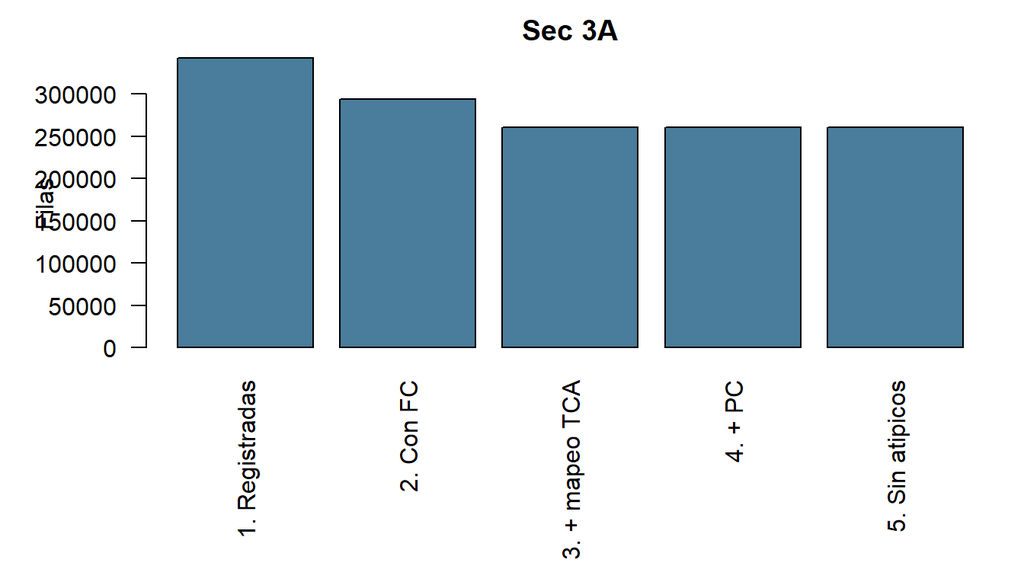

Figura 1: Dónde se pierde cada observación, por sección

**Lectura.** El embudo muestra en qué paso se pierde cada observación. Eso importa porque orienta el trabajo pendiente: no tiene sentido ampliar el crosswalk si la pérdida principal está en los factores de conversión, ni al revés.

## 4 Los cuatro vehículos de fortificación

Esta es la verificación que decide si los indicadores de cobertura del reporte R3 son defendibles. La pregunta no es cuánto cubre el pipeline en general, sino **si cubre bien los alimentos que importan para fortificación**.

Tabla 2: Cobertura específica de los vehículos de fortificación

| Vehiculo | Seccion | Filas | Entran al calculo | % cobertura |
| --- | --- | --- | --- | --- |
| Aceite | Sec 2 | 5,880 | 5,854 | 99.6% |
| Aceite | Sec 3A | 11,481 | 11,155 | 97.2% |
| Arroz | Sec 2 | 4,639 | 4,595 | 99.1% |
| Arroz | Sec 3A | 16,405 | 16,192 | 98.7% |
| Azucar | Sec 2 | 4,186 | 4,186 | 100% |
| Azucar | Sec 3A | 8,723 | 8,684 | 99.6% |
| Harina de trigo | Sec 3A | 890 | 882 | 99.1% |

- **Aceite**: 98% — Cobertura alta — el indicador es defendible sin salvedad.
- **Arroz**: 98.8% — Cobertura alta — el indicador es defendible sin salvedad.
- **Azucar**: 99.7% — Cobertura alta — el indicador es defendible sin salvedad.
- **Harina de trigo**: 99.1% — Cobertura alta — el indicador es defendible sin salvedad.

**NotaDefinición auditable**

Los vehículos se identifican por patrón de texto sobre la descripción de la ENGIH, definido en `reports/_comun.R`. La definición es editable y está en un solo lugar: si se decide incluir o excluir un producto, cambia acá y se propaga a todos los reportes.

## 5 Qué queda fuera, y cuánto pesa

Tabla 3: Alimentos con mayor volumen de observaciones que NO entran al cálculo

| seccion | descripcion | motivo | filas |
| --- | --- | --- | --- |
| Sec 3A | Caldo de pollo (Sopita Concentrada) | Sin mapeo a tabla de composicion | 18,084 |
| Sec 3A | Agua purificada (Dasani, Planeta Azul y similares) | Sin mapeo a tabla de composicion | 7,774 |
| Sec 3A | Plátano verde | Sin factor de conversion | 7,690 |
| Sec 3A | Guineo verde (guineíto) | Sin factor de conversion | 5,577 |
| Sec 3A | Aguacate | Sin factor de conversion | 2,417 |
| Sec 3A | Tomate Barceló o Bugalú | Sin factor de conversion | 1,982 |
| Sec 2 | PLÁTANO VERDE | Sin factor de conversion | 1,836 |
| Sec 3A | Plátano maduro | Sin factor de conversion | 1,815 |
| Sec 3A | Sazón líquido | Sin mapeo a tabla de composicion | 1,694 |
| Sec 3A | Ají gustoso o cachucha | Sin factor de conversion | 1,616 |
| Sec 2 | GUINEITO VERDE | Sin factor de conversion | 1,513 |
| Sec 3A | Apio planta, apio gusto | Sin factor de conversion | 1,449 |
| Sec 3A | Naranja agria | Sin factor de conversion | 1,394 |
| Sec 3A | Guineo maduro (banano) | Sin factor de conversion | 1,313 |
| Sec 3A | Berenjena corriente | Sin factor de conversion | 1,068 |
| Sec 3A | Margarina | Sin factor de conversion | 1,013 |
| Sec 3A | Tomates de ensalada | Sin factor de conversion | 946 |
| Sec 3A | Limón agrio | Sin factor de conversion | 920 |
| Sec 3A | Cilantro | Sin factor de conversion | 887 |
| Sec 3A | Tayota | Sin factor de conversion | 815 |

Tabla 4: Motivo de exclusión, agregado

| Seccion | Motivo | Filas |
| --- | --- | --- |
| Sec 2 | Sin factor de conversion | 4,413 |
| Sec 2 | Sin mapeo a tabla de composicion | 20 |
| Sec 2 | Marcada atipica | 11 |
| Sec 3A | Sin factor de conversion | 48,683 |
| Sec 3A | Sin mapeo a tabla de composicion | 33,303 |
| Sec 3A | Marcada atipica | 45 |
| Sec 3A | Sin cantidad | 1 |

## 6 Estado del crosswalk

Tabla 5: Mapeo de alimentos de la ENGIH a tablas de composición

[output not shown]

Tabla 6: Naturaleza de las equivalencias asignadas

| Tipo de equivalencia | Filas |
| --- | --- |
| directa | 181 |
| (sin declarar) | 114 |
| sustituto_por_criterio | 106 |
| requiere_revision | 5 |
| categoria_compuesta | 1 |

La distinción entre equivalencia **directa** y **sustituto por criterio** no es cosmética: declara en qué casos el alimento dominicano corresponde exactamente a la entrada de la tabla de composición, y en cuáles se aplicó un criterio. Las filas marcadas *(sin declarar)* son un pendiente conocido, heredado de la fase inicial del proyecto.

## 7 Control de calidad: valores atípicos

El Paso 7 de la guía del modelo de base exige identificación de valores atípicos. El pipeline los detecta por alimento —comparando cada observación contra la distribución del mismo `enhance_id`— y los **marca sin eliminarlos**, para que la decisión de tratamiento sea explícita y reversible.

Tabla 7: Observaciones marcadas como atípicas

| Seccion | Filas evaluadas | Marcadas atipicas | % del total |
| --- | --- | --- | --- |
| Sec 2 | 43,404 | 11 | 0% |
| Sec 3A | 260,059 | 45 | 0% |

**ImportanteDependencia que conviene declarar**

La detección de atípicos agrupa por `enhance_id`. Para las filas sin mapeo, la comparación mezclaría alimentos no relacionados, así que la defensa es efectiva solo donde el crosswalk está completo. Es una razón adicional —además de la nutricional— para priorizar el mapeo.

## 8 Adaptaciones metodológicas aplicadas

Lo que el numeral 4.2 de los TdR pide documentar explícitamente.

| Situación encontrada | Adaptación | Estado |
| --- | --- | --- |
| Unidades no estándar sin factor de conversión publicado | Factor empírico derivado del propio crudo (mediana por combinación alimento-presentación), clasificado por dispersión | Aplicado |
| Alimentos sin peso por unidad en ninguna fuente | Pesaje directo en mercado dominicano, documentado con evidencia fotográfica | Aplicado a casos puntuales |
| Alimentos ausentes de la tabla INCAP | Uso de FNDDS como fuente secundaria, declarada fila por fila en la columna `fuente` | Aplicado |
| Período de medición variable entre hogares | Uso de días observados por hogar en lugar de constante | Aplicado |
| Sección 3B (alimentos fuera del hogar) | Excluida: requiere factores de receta y rendimiento no disponibles | Decisión explícita de alcance |
| Embarazo y lactancia en el cálculo de EMA | No ajustado: la variable no existe en la ENGIH | Limitación declarada |

## 9 Limitaciones

- Cobertura del cálculo: Sec 2 90.7%, Sec 3A 76%. Ningún resultado de consumo o ingesta debe citarse sin este dato.
- Las observaciones que quedan fuera **no son una muestra aleatoria**: se concentran en alimentos sin factor de conversión o sin mapeo. Los agregados representan lo cubierto, no el total de la dieta.
- Los pesos por unidad de varios alimentos son estimaciones a partir de fuentes externas o de pesaje propio, no medición de la encuesta.
- El cálculo de EMA no ajusta por embarazo ni lactancia, usa peso fijo por sexo y asume actividad física moderada, según los supuestos de la guía de referencia.
- El diseño muestral complejo (estrato, UPM, factor de expansión) está disponible en los datos; mientras no se aplique, los intervalos de confianza están subestimados.

## 10 Conclusión sobre factibilidad

La ENGIH 2018 permite implementar la metodología del modelo de base. Al momento de generar este reporte, 4 de 4 vehículos de fortificación alcanzan cobertura suficiente para reportar indicadores, y la cobertura general del cálculo es de 76% en Sección 3A.

Lo que limita el alcance no es la encuesta: es el estado de completitud de las tablas auxiliares (factores de conversión, porción comestible, crosswalk), que sigue ampliándose. Cada ampliación mejora estas cifras sin cambiar el método, y este reporte lo refleja automáticamente.

*Generado desde el pipeline reproducible del proyecto. Código y datos: `scripts/01_import.R` a `scripts/04_equivalente_adulto.R`.*